# Week 2 Lab

1. Using the `delay_2022` data, plot the five stations with the highest mean delays. Facet the graph by `line`
2. Using the `opendatatoronto` package, download the data on mayoral campaign contributions for 2014. Hints:
   - find the ID code you need for the package you need by searching for ‘campaign’ in the `all_data` tibble above
   - you will then need to `list_package_resources` to get ID for the data file
   - note: the 2014 file you will get from `get_resource` has a bunch of different campaign contributions, so just keep the data that relates to the Mayor election
3. Clean up the data format (fixing the parsing issue and standardizing the column names using `janitor`)
4. Summarize the variables in the dataset. Are there missing values, and if so, should we be worried about them? Is every variable in the format it should be? If not, create new variable(s) that are in the right format.
5. Visually explore the distribution of values of the contributions. What contributions are notable outliers? Do they share a similar characteristic(s)? It may be useful to plot the distribution of contributions without these outliers to get a better sense of the majority of the data.
6. List the top five candidates in each of these categories:
   - total contributions
   - mean contribution
   - number of contributions
7. Repeat 5 but without contributions from the candidates themselves.
8. How many contributors gave money to more than one candidate?

```r
library(opendatatoronto)
library(tidyverse)
library(stringr)
library(skimr) # EDA
library(visdat) # EDA
library(janitor)
library(lubridate)
library(ggrepel)
all_data <- list_packages(limit = 500)
head(all_data)
```

| title | id | topics | civic_issues | publisher | excerpt | dataset_category | num_resources | formats | refresh_rate | last_refreshed |
| --- | --- | --- | --- | --- | --- | --- | --- | --- | --- | --- |
| Building Permits - Pool Enclosures | f2ca7883-f6a6-48ec-b98c-b8efca638afc | Development and infrastructure,Permits and licenses | NA | Toronto Building | Permits issued within the past 10 years (from date of dataset generation/refresh) dealing with pools. Target is permits with specific 'Work Type' of 'Pool Fence Enclosure', and others that contain 'po… | Table | 5 | XLS,JSON,CSV,XML | Weekly | 2023-01-23 |
| Building Permits - Green Roofs | 9425a29e-6b01-40f0-94c2-9a7b9efe8696 | Development and infrastructure,Permits and licenses | Climate change | Toronto Building | Green Roof-related building permit applications. | Table | 5 | XLS,JSON,CSV,XML | Weekly | 2023-01-23 |
| Daily Shelter & Overnight Service Occupancy & Capacity | 21c83b32-d5a8-4106-a54f-010dbe49f6f2 | Community services,City government | Affordable housing | Shelter, Support & Housing Administration | Daily occupancy and capacity data for City of Toronto funded shelter and overnight service programs. | Table | 12 | JSON,CSV,XML | Daily | 2023-01-23 |
| Traffic Cameras | a3309088-5fd4-4d34-8297-77c8301840ac | Transportation | NA | Transportation Services | This dataset contains all the locations (latitude, longitude) of the traffic cameras within the City of Toronto. Associated/Reference URLs are also included with this dataset. | Map | 12 | XSD,SHP,CSV,XLS,JSON,GPKG,GEOJSON | As available | 2023-01-23 |
| BodySafe | c4052ff7-a09d-4eaf-84e6-6669519f413d | City government,Public safety,Health | NA | Toronto Public Health | This dataset contains the Personal Service Settings (PSS) annual health inspection results in accordance to the Ministry of Health and Long-Term Care's Infection Prevention and Control Best Practices … | Map | 9 | GPKG,SHP,CSV,GEOJSON | Daily | 2023-01-23 |
| Chemical Tracking (ChemTrac) | ae8eebf8-42fe-426f-b5f8-5baa8ff0bfb8 | Public safety,Health,Environment | NA | Toronto Public Health | This dataset report information each year about the use and release of 25 'priority substances' as contaminants in Toronto's environment and of concern for health. | Table | 6 | XML,JSON,CSV,WEB,XLS | Daily | 2023-01-23 |

```r
res <- list_package_resources("996cfe8d-fb35-40ce-b569-698d51fc683b")
# obtained code from searching data frame above
res <- res |> mutate(year = str_extract(name, "202.?"))
delay_2022_ids <- res |> filter(year==2022) |> select(id) |> pull()
delay_2022 <- get_resource(delay_2022_ids)
# make the column names nicer to work with
delay_2022 <- clean_names(delay_2022)
```

Get the five stations with the highest mean delay. We will only consider stations that appear at least more than once.

```r
freq_table = data.frame(table(delay_2022$station))

truth = c()
for (i in 1:nrow(delay_2022)){
  if (freq_table$Freq[which(freq_table$Var1 == delay_2022$station[i])]>1){
    truth = c(truth, TRUE)
  }
  else{
    truth = c(truth, FALSE)
  }
}

temp_1 = delay_2022
temp_1$truth = truth

temp_2 = temp_1 |>
  filter(temp_1$truth)

temp_3 = temp_2 |>
  group_by(station)

summarize(temp_3, Mean_Delay = mean(min_delay)) |>
            arrange(desc(Mean_Delay))
```

| station | Mean_Delay |
| --- | --- |
| SHEPPARD WEST TO WILSO | 20.0000000 |
| VICTORIA PARK TO WARDE | 16.0000000 |
| SRT LINE | 14.5000000 |
| UNION STATION - ST AND | 14.0000000 |
| ELLESMERE STATION | 12.1250000 |
| GUNN BUILDING | 11.1666667 |
| KENNEDY SRT STATION | 10.9265537 |
| SHEPPARD LINE | 9.5000000 |
| WILSON SOUTH HOSTLER | 9.0000000 |
| DUPONT STATION | 7.2592593 |

[output cut: 148 more lines]

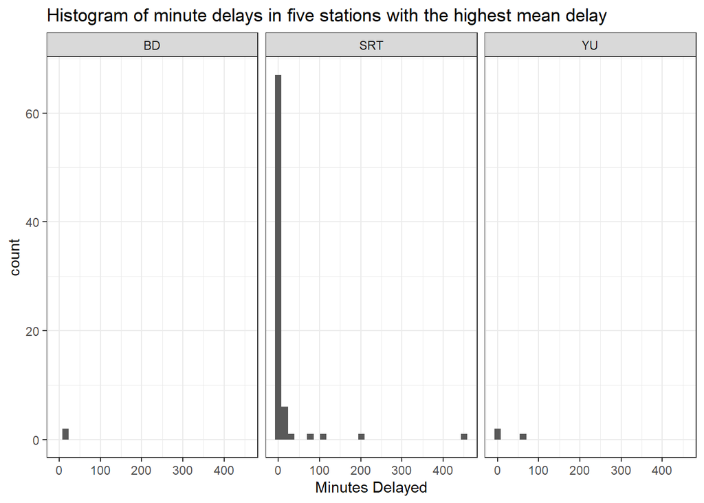

```r
top_5_mean = delay_2022 |>
  filter(station == "SHEPPARD WEST TO WILSO"|
           station == "VICTORIA PARK TO WARDE"|
           station == "SRT LINE"|
           station == "UNION STATION - ST AND "|
           station == "ELLESMERE STATION")
ggplot(data = top_5_mean)+
  geom_histogram(aes(x=min_delay))+
  facet_wrap(~line)+
  labs(title = "Histogram of minute delays in five stations with the highest mean delay")+
  xlab("Minutes Delayed")+
  theme_bw()
```

```r
library(opendatatoronto)
#search by title
campaign_package = search_packages("campaign contributions 2014")

#get the id
id_2014 = campaign_package$id

temp = list_package_resources(id_2014)

temp
```

| name | id | format | last_modified |
| --- | --- | --- | --- |
| campaign-contributions-2014-data | 5b230e92-0a22-4a15-9572-0b19cc222985 | ZIP | 2019-07-23 |
| campaign-contributions-2014-readme-xls | aaf736f4-7468-4bda-9a66-4bb592e9c63c | XLS | 2019-07-23 |

```r
#5b230e92-0a22-4a15-9572-0b19cc222985 is the id

mayor_2014 = get_resource("5b230e92-0a22-4a15-9572-0b19cc222985")$`2_Mayor_Contributions_2014_election.xls`
head(mayor_2014)
```

| 2014 Municipal Election - List of Contributors to Mayoralty Candidates | ...2 | ...3 | ...4 | ...5 | ...6 | ...7 | ...8 | ...9 | ...10 | ...11 | ...12 | ...13 |
| --- | --- | --- | --- | --- | --- | --- | --- | --- | --- | --- | --- | --- |
| Contributor's Name | Contributor's Address | Contributor's Postal Code | Contribution Amount | Contribution Type Desc | Goods or Service Desc | Contributor Type Desc | Relationship to Candidate | President/ Business Manager | Authorized Representative | Candidate | Office | Ward |
| A D'Angelo, Tullio | NA | M6A 1P5 | 300 | Monetary | NA | Individual | NA | NA | NA | Ford, Rob | Mayor | NA |
| A Strazar, Martin | NA | M2M 3B8 | 300 | Monetary | NA | Individual | NA | NA | NA | Ford, Rob | Mayor | NA |
| A'Court, K Susan | NA | M4M 2J8 | 36 | Monetary | NA | Individual | NA | NA | NA | Chow, Olivia | Mayor | NA |
| A'Court, K Susan | NA | M4M 2J8 | 100 | Monetary | NA | Individual | NA | NA | NA | Chow, Olivia | Mayor | NA |
| A'Court, K Susan | NA | M4M 2J8 | 100 | Monetary | NA | Individual | NA | NA | NA | Chow, Olivia | Mayor | NA |

We will clean the data set in 3.

```r
library(janitor)
#we can fix the parsing issue
mayor_2014 = row_to_names(mayor_2014, row_number= 1)

head(mayor_2014)
```

| Contributor's Name | Contributor's Address | Contributor's Postal Code | Contribution Amount | Contribution Type Desc | Goods or Service Desc | Contributor Type Desc | Relationship to Candidate | President/ Business Manager | Authorized Representative | Candidate | Office | Ward |
| --- | --- | --- | --- | --- | --- | --- | --- | --- | --- | --- | --- | --- |
| A D'Angelo, Tullio | NA | M6A 1P5 | 300 | Monetary | NA | Individual | NA | NA | NA | Ford, Rob | Mayor | NA |
| A Strazar, Martin | NA | M2M 3B8 | 300 | Monetary | NA | Individual | NA | NA | NA | Ford, Rob | Mayor | NA |
| A'Court, K Susan | NA | M4M 2J8 | 36 | Monetary | NA | Individual | NA | NA | NA | Chow, Olivia | Mayor | NA |
| A'Court, K Susan | NA | M4M 2J8 | 100 | Monetary | NA | Individual | NA | NA | NA | Chow, Olivia | Mayor | NA |
| A'Court, K Susan | NA | M4M 2J8 | 100 | Monetary | NA | Individual | NA | NA | NA | Chow, Olivia | Mayor | NA |
| Aaron, Robert B | NA | M6B 1H7 | 250 | Monetary | NA | Individual | NA | NA | NA | Tory, John | Mayor | NA |

```r
#and standardize the column names
mayor_2014 = clean_names(mayor_2014)

head(mayor_2014)
```

| contributors_name | contributors_address | contributors_postal_code | contribution_amount | contribution_type_desc | goods_or_service_desc | contributor_type_desc | relationship_to_candidate | president_business_manager | authorized_representative | candidate | office | ward |
| --- | --- | --- | --- | --- | --- | --- | --- | --- | --- | --- | --- | --- |
| A D'Angelo, Tullio | NA | M6A 1P5 | 300 | Monetary | NA | Individual | NA | NA | NA | Ford, Rob | Mayor | NA |
| A Strazar, Martin | NA | M2M 3B8 | 300 | Monetary | NA | Individual | NA | NA | NA | Ford, Rob | Mayor | NA |
| A'Court, K Susan | NA | M4M 2J8 | 36 | Monetary | NA | Individual | NA | NA | NA | Chow, Olivia | Mayor | NA |
| A'Court, K Susan | NA | M4M 2J8 | 100 | Monetary | NA | Individual | NA | NA | NA | Chow, Olivia | Mayor | NA |
| A'Court, K Susan | NA | M4M 2J8 | 100 | Monetary | NA | Individual | NA | NA | NA | Chow, Olivia | Mayor | NA |
| Aaron, Robert B | NA | M6B 1H7 | 250 | Monetary | NA | Individual | NA | NA | NA | Tory, John | Mayor | NA |

We can first check for missing values using skim package.

```r
skim(mayor_2014)
```

Data summary

| Name | mayor_2014 |
| --- | --- |
| Number of rows | 10199 |
| Number of columns | 13 |
| _______________________ |  |
| Column type frequency: |  |
| character | 13 |
| ________________________ |  |
| Group variables | None |

**Variable type: character**

| skim_variable | n_missing | complete_rate | min | max | empty | n_unique | whitespace |
| --- | --- | --- | --- | --- | --- | --- | --- |
| contributors_name | 0 | 1 | 4 | 31 | 0 | 7545 | 0 |
| contributors_address | 10197 | 0 | 24 | 26 | 0 | 2 | 0 |
| contributors_postal_code | 0 | 1 | 7 | 7 | 0 | 5284 | 0 |
| contribution_amount | 0 | 1 | 1 | 18 | 0 | 209 | 0 |
| contribution_type_desc | 0 | 1 | 8 | 14 | 0 | 2 | 0 |
| goods_or_service_desc | 10188 | 0 | 11 | 40 | 0 | 9 | 0 |
| contributor_type_desc | 0 | 1 | 10 | 11 | 0 | 2 | 0 |
| relationship_to_candidate | 10166 | 0 | 6 | 9 | 0 | 2 | 0 |
| president_business_manager | 10197 | 0 | 13 | 16 | 0 | 2 | 0 |
| authorized_representative | 10197 | 0 | 13 | 16 | 0 | 2 | 0 |
| candidate | 0 | 1 | 9 | 18 | 0 | 27 | 0 |
| office | 0 | 1 | 5 | 5 | 0 | 1 | 0 |
| ward | 10199 | 0 | NA | NA | 0 | 0 | 0 |

We first see that the ward variable is useless as all the values are missing. We also remove other variables that have that have $99 \%$ of the values missing, except the 8th column which describes the relationship of the contributor to the candidate.

```r
mayor_2014 = mayor_2014 |>
  select(-c(2,6,9,10,13))
```

The relationship to candidate column is relevant.

```r
mayor_2014$relationship_to_candidate[which(!is.na(mayor_2014$relationship_to_candidate))]
```

```
##  [1] "Candidate" "Candidate" "Candidate" "Candidate" "Candidate" "Candidate"
##  [7] "Candidate" "Candidate" "Candidate" "Candidate" "Candidate" "Candidate"
## [13] "Candidate" "Candidate" "Candidate" "Candidate" "Spouse"    "Spouse"
## [19] "Candidate" "Candidate" "Candidate" "Candidate" "Candidate" "Candidate"
## [25] "Candidate" "Candidate" "Candidate" "Candidate" "Candidate" "Candidate"
## [31] "Candidate" "Candidate" "Spouse"
```

We want to know whether or not candidate made any contribution for 7. Hence, we make a new column where it’s 1 if the candidate contributed themselves, and 0 otherwise.

```r
#replace NA with FALSE
mayor_2014$relationship_to_candidate[which(is.na(mayor_2014$relationship_to_candidate))]=
  FALSE
#make a column of 1 if the contributor is candidate
#0 otherwise
mayor_2014 = mayor_2014 |>
  mutate(relationship = ifelse(relationship_to_candidate == "Candidate",1,0)) |>
  select(-6)
```

Contribution amount should be in numeric.

```r
mayor_2014$contribution_amount=as.numeric(mayor_2014$contribution_amount)
```

The “Office” variable has the same value for each data point, so we may remove it.

```r
unique(mayor_2014$office)
```

```
## [1] "Mayor"
```

```r
mayor_2014 = mayor_2014 |>
  select(-7)
```

We will first look at summary statistics for the contribution amount.

```r
summary(mayor_2014$contribution_amount)
```

```
##    Min. 1st Qu.  Median    Mean 3rd Qu.    Max.
##       1     100     300     608     500  508225
```

The median is smaller than the mean by 308 dollars, so this may suggest some higher-end donations that skew the distribution.

The maximum of 508225 dollars is also notable.

Next, we will look at composition of the contribution type.

```r
unique(mayor_2014$contribution_type_desc)
```

```
## [1] "Monetary"       "Goods/Services"
```

```r
temp = mayor_2014$contribution_type_desc
#percentage of monetary donation
(length(which(temp == "Monetary"))/length(temp) )*100
```

```
## [1] 99.89215
```

And we look at the composition of the contributor type.

```r
unique(mayor_2014$contributor_type_desc)
```

```
## [1] "Individual"  "Corporation"
```

```r
temp = mayor_2014$contributor_type_desc
#percentage of individual donation
(length(which(temp == "Individual"))/length(temp) )*100
```

```
## [1] 99.98039
```

We first graph a histogram of the contribution amounts.

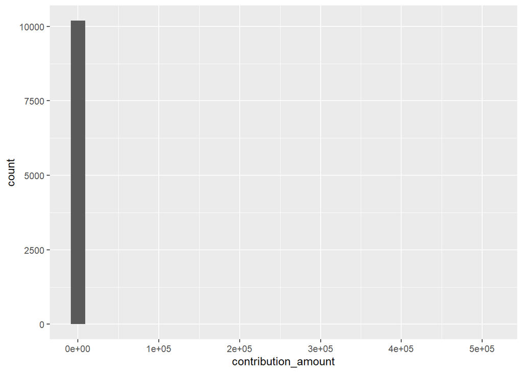

```r
ggplot(data = mayor_2014, aes(x=contribution_amount))+
  geom_histogram()
```

The histogram breaks because of outliers. We will remove contributions of more than 50000 dollars. There are 2 of them.

```r
length(which(mayor_2014$contribution_amount > 50000))
```

```
## [1] 2
```

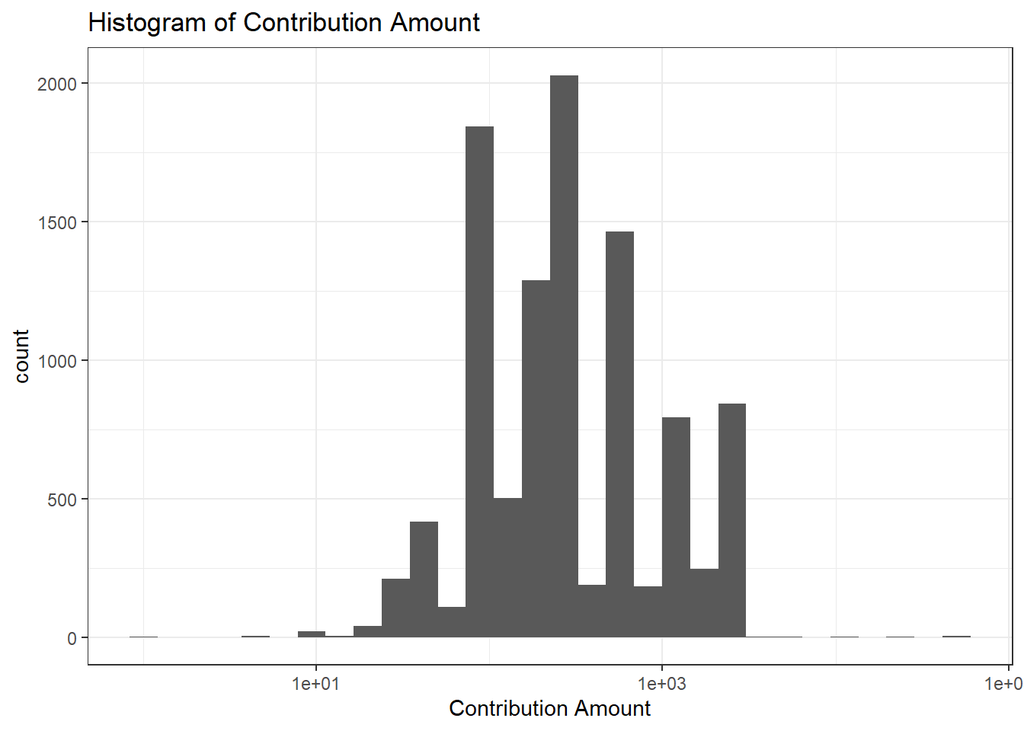

```r
temp = mayor_2014 |>
  filter(contribution_amount <=50000)


ggplot(data = temp)+
  geom_histogram(aes(x=contribution_amount))+
  xlab("Contribution Amount")+
  scale_x_log10()+
  labs(title = "Histogram of Contribution Amount")+
  theme_bw()
```

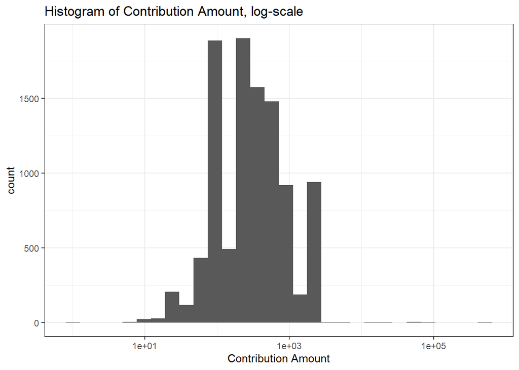

```r
#We can also plot it on the log-scale
#in which case we do not need to remove the outlier

ggplot(data = mayor_2014)+
  geom_histogram(aes(x=contribution_amount))+
  xlab("Contribution Amount")+
  scale_x_log10()+
  labs(title = "Histogram of Contribution Amount, log-scale")+
  theme_bw()
```

Notably, there’s an outlier with the contribution of 508224.73.

```r
mayor_2014 |>
  filter(contribution_amount == 508224.73)
```

| contributors_name | contributors_postal_code | contribution_amount | contribution_type_desc | contributor_type_desc | candidate | relationship |
| --- | --- | --- | --- | --- | --- | --- |
| Ford, Doug | M9A 2C3 | 508224.7 | Monetary | Individual | Ford, Doug | 1 |

This contribution turns out to be Doug Ford self-financing his own campaign.

A frequency table can also be interesting. We print top 15 contribution amount with respect to frequency.

```r
sort(table(mayor_2014$contribution_amount), decreasing = TRUE)[1:15]
```

```
##
##  100  500  300  200 2500 1000  250   50  150   25  750 1500  400 2000   60
## 1767 1392 1367 1245  825  735  605  323  243  181  133  130  118   93   92
```

Another thing of interest is the number of “small” contribution. OpenSecrets, a non-profit organization that tracks campaign financing, defines small contributions as contribution of less than 200 dollars. So we will use this definition.

```r
small = length(which(mayor_2014$contribution_amount < 200))

#the percentage of small contribution

small/nrow(mayor_2014) * 100
```

```
## [1] 31.28738
```

So less than half of the donations were “small” contributions.

```r
temp = mayor_2014 |>
  group_by(candidate)

total_contribution = temp|>
  summarize(Total = sum(contribution_amount))|>
  arrange(desc(Total))

total_contribution
```

| candidate | Total |
| --- | --- |
| Tory, John | 2767868.71 |
| Chow, Olivia | 1638265.90 |
| Ford, Doug | 889897.30 |
| Ford, Rob | 387648.17 |
| Stintz, Karen | 242805.00 |
| Soknacki, David | 132431.00 |
| Goldkind, Ari | 41124.63 |
| Thomson, Sarah | 34627.95 |
| Di Paola, Rocco | 21126.00 |
| Underhill, Richard | 15660.00 |

[output cut: 17 more lines]

So the top five candidates in total contribution is Tory, Chow, Ford, Doug, Ford Rob, and Stintz.

```r
temp = mayor_2014 |>
  group_by(candidate)

mean_contribution = temp|>
  summarize(Mean = mean(contribution_amount))|>
  arrange(desc(Mean))

mean_contribution
```

| candidate | Mean |
| --- | --- |
| Sniedzins, Erwin | 2025.0000 |
| Syed, Hïmy | 2018.0000 |
| Ritch, Carlie | 1886.6667 |
| Ford, Doug | 1456.4604 |
| Clarke, Kevin | 1200.0000 |
| Di Paola, Rocco | 1173.6667 |
| Tory, John | 1063.7466 |
| Gardner, Norman | 1000.0000 |
| Stintz, Karen | 995.1025 |
| Kalevar, Chai | 900.0000 |

[output cut: 17 more lines]

So the top five candidates in mean contribution is Sniedzin, Syed, Ritch, Ford, Doug and Clarke.

```r
temp = mayor_2014 |>
  group_by(candidate)

num_contribution = temp|>
  summarize(num = length(contribution_amount))|>
  arrange(desc(num))

num_contribution
```

| candidate | num |
| --- | --- |
| Chow, Olivia | 5708 |
| Tory, John | 2602 |
| Ford, Doug | 611 |
| Ford, Rob | 538 |
| Soknacki, David | 314 |
| Stintz, Karen | 244 |
| Goldkind, Ari | 47 |
| Underhill, Richard | 41 |
| Thomson, Sarah | 40 |
| Di Paola, Rocco | 18 |

[output cut: 17 more lines]

So the top five candidates in number of contribution is Chow, Tory, Ford, Doug, Ford, Rob and Soknacki.

We remove donation made by the candidates themselves

```r
remove_candidate = mayor_2014 |>
  filter(relationship == 0)

#the maximum donation is now 3660.

max(remove_candidate$contribution_amount)
```

```
## [1] 3660
```

We repeat Q6.

```r
temp = remove_candidate |>
  group_by(candidate)

total_contribution = temp|>
  summarize(Total = sum(contribution_amount))|>
  arrange(desc(Total))

total_contribution
```

| candidate | Total |
| --- | --- |
| Tory, John | 2765368.7 |
| Chow, Olivia | 1635765.9 |
| Ford, Doug | 331172.6 |
| Stintz, Karen | 242805.0 |
| Ford, Rob | 174509.5 |
| Soknacki, David | 132431.0 |
| Thomson, Sarah | 27702.4 |
| Goldkind, Ari | 17501.0 |
| Underhill, Richard | 15660.0 |
| Di Paola, Rocco | 15126.0 |

[output cut: 7 more lines]

So the top five candidates in total contribution is Tory, Chow, Ford, Doug, Stintz, Rob, Ford.

```r
temp = remove_candidate|>
  group_by(candidate)

mean_contribution = temp|>
  summarize(Mean = mean(contribution_amount))|>
  arrange(desc(Mean))

mean_contribution
```

| candidate | Mean |
| --- | --- |
| Ritch, Carlie | 1886.6667 |
| Sniedzins, Erwin | 1866.6667 |
| Tory, John | 1063.1944 |
| Gardner, Norman | 1000.0000 |
| Tiwari, Ramnarine | 1000.0000 |
| Stintz, Karen | 995.1025 |
| Di Paola, Rocco | 889.7647 |
| Thomson, Sarah | 729.0105 |
| Ford, Doug | 544.6917 |
| Billard, Jeff | 495.5000 |

[output cut: 7 more lines]

So the top five candidates in mean contribution is Ritch, Sniedzins, Tory, Gardner, and Tiwari.

```r
temp = remove_candidate |>
  group_by(candidate)

num_contribution = temp|>
  summarize(num = length(contribution_amount))|>
  arrange(desc(num))

num_contribution
```

| candidate | num |
| --- | --- |
| Chow, Olivia | 5707 |
| Tory, John | 2601 |
| Ford, Doug | 608 |
| Ford, Rob | 531 |
| Soknacki, David | 314 |
| Stintz, Karen | 244 |
| Goldkind, Ari | 46 |
| Underhill, Richard | 41 |
| Thomson, Sarah | 38 |
| Di Paola, Rocco | 17 |

[output cut: 7 more lines]

So the top five candidates in number of contribution is Chow, Tory, Ford, Doug, Ford, Rob and Soknacki.

Since it’s possible for two people to have the same name, we first filter by the address. We will assume that people with the same name and the same address is a one person, even though it’s possible that two people with the same name are living in the same address.

```r
#choosing contributor address that appears twice.
temp = mayor_2014|>
  group_by(contributors_postal_code)|>
  filter(length(contributors_postal_code) > 1)

#We then group by name, choosing people that appear twice.

temp = temp|>
  group_by(contributors_name)|>
  filter(length(contributors_name)>1)

#the number of people who made more than one contribution is

length(unique(temp$contributors_name))
```

```
## [1] 1849
```